# Introduction

The lack of standardisation in sensory characterisation across beverage types makes this project a bit of a conceptual nightmare.

1. The levels of each sensory wheel can differ. Some have two levels and some three.
2. The conceptual categorisation of the levels can be multi-sensory (organolyptic, aroma, mouthfeel, etc.) or even degree of attribution (eg., primary, secondary, fermentation-derived)
3. The part-of-speech can differ. Some use adjectives for higher levels while attribute descriptor level is a noun (eg., level1=spicy, level3=spice). This is even swapped in some cases, so not much consistency within a wheel and between wheels.
4. POV is from assessor or from the product. Perception vs Conception

This then has implications for language processing. If the part of speech is inconsistent then it makes it difficult to code for, let alone standardise. The most resolved concepts are in food ontology and food chemistry. Matrix effect confounds this. Description of complexity, lack of clarity leading to "complexity". Consistency usually comes from expert panels or strict sensory analysis methods.

# Sensory wheel generator: Anne C. Noble wine aroma

The sensory wheel can be generated from a single product to a number of products. It can also be generated based on free-text descriptions. The formats are broken down below. The sensory wheel can be generated from a

- frequency-of-citation (foc) table
- Free-text (ftx) data

The ftx data is transformed into foc using the NLP function from the package. From thereon, the foc is merged with a chosen sensory wheel dictionary creating

- Static sensory wheel
- Interactive sensory wheel

The static plot uses opacity to indicate the frequency of each attribute. The interactive plot uses the wedge sizes to indicate frequency. There is a merit for using both of these. In examples with a small set of attributes, both versions work. In examples with large number of attributes, see the examples from free-text data, the interactive format is preferred. This is because the wedge sizes compresses the lower frequency attributes and focuses attention on the higher frequency attributes.

## Free-text (ft) table input

This takes the table input as shown below and generates frequency-of-citation (foc). The ft table input into the freeTextProcessor produces the foc table. Note the column names must be as shown.

|  | sample_codes | description |
| --- | --- | --- |
| 0 | W1 | nuanced, very fresh, slightly developed taste ... |
| 1 | W2 | fruity, very fresh taste with hints of red app... |
| 2 | W3 | fruity taste with hints of yellow apples, bisc... |
| 3 | W4 | complex, slightly developed, very fresh taste ... |
| 4 | W5 | fruity, very fresh, developed taste with hints... |
| 5 | W6 | nuanced, very fresh taste with hints of red ap... |
| 6 | W7 | slightly developed, very fresh taste with hint... |
| 7 | W8 | nuanced, very fresh taste with hints of red ap... |
| 8 | W9 | nuanced, very fresh taste with hints of red ap... |
| 9 | W10 | developed, nuanced, very fresh taste with hint... |
| 10 | W11 | complex, very fresh, slightly developed taste ... |
| 11 | W12 | complex, developed, very fresh taste with hint... |
| 12 | W13 | nuanced, very fresh taste with hints of cask, ... |
| 13 | W14 | complex, developed, very fresh taste with hint... |
| 14 | W15 | fruity taste with hints of yellow apples, marz... |

The Frequency of citation(foc) table can be an input directly into the sensory wheel generator. Note that the foc has a set two column format as shown below.

|  | descriptor | Frequency |
| --- | --- | --- |
| 0 | cherry | 86 |
| 1 | ethanol | 56 |
| 2 | frankincense | 56 |
| 3 | caramel | 56 |
| 4 | cut grass | 56 |
| 5 | black pepper | 42 |
| 6 | butter | 42 |
| 7 | leather | 42 |
| 8 | phenolic | 24 |
| 9 | cinnamon | 24 |
| 10 | candy | 24 |
| 11 | soil | 24 |
| 12 | coffee | 23 |
| 13 | violet | 23 |
| 14 | licorice | 23 |

The foc tables are matched against the template sensory wheel selected ("wine aroma" or "beer aroma") with further option currently under development. This generates a matched attributes table like below.

|  | index | family | subcategory | descriptor | colour | Frequency |
| --- | --- | --- | --- | --- | --- | --- |
| 0 | 13 | Fruity | Stone Fruit | cherry | #ff7f24 | 86.0 |
| 1 | 41 | Green/Vegetative | Green | cut grass | #065535 | 56.0 |
| 2 | 83 | Roasted/Nutty | Caramelized | caramel | #ffd700 | 56.0 |
| 3 | 101 | Chemical | Solvent | ethanol | #00ffff | 56.0 |
| 4 | 65 | Woody/Resinous | Resin | frankincense | #3d261c | 56.0 |
| 5 | 54 | Spicy | Pungent Spice | black pepper | #cd853f | 42.0 |
| 6 | 92 | Fermented | Dairy | butter | #9fa91f | 42.0 |
| 7 | 74 | Earthy | Animalic | leather | #8e847a | 42.0 |
| 8 | 50 | Spicy | Sweet Spice | cinnamon | #cd853f | 24.0 |
| 9 | 71 | Earthy | Earthy | soil | #8e847a | 24.0 |
| 10 | 107 | Chemical | Medicinal | phenolic | #00ffff | 24.0 |
| 11 | 89 | Sweet/Confectionery | Confectionery | candy | #b00b69 | 24.0 |
| 12 | 77 | Roasted/Nutty | Roasted | coffee | #ffd700 | 23.0 |
| 13 | 84 | Roasted/Nutty | Caramelized | toffee | #ffd700 | 23.0 |
| 14 | 66 | Woody/Resinous | Smoky | smoke | #3d261c | 23.0 |

The sunburst of the wheel is generated from the template wheel. An interactive format and a static format are generated simultaneously. The wheel currently aggregates products into a single representative wheel. It still accepts a single product, an example output is shown below.

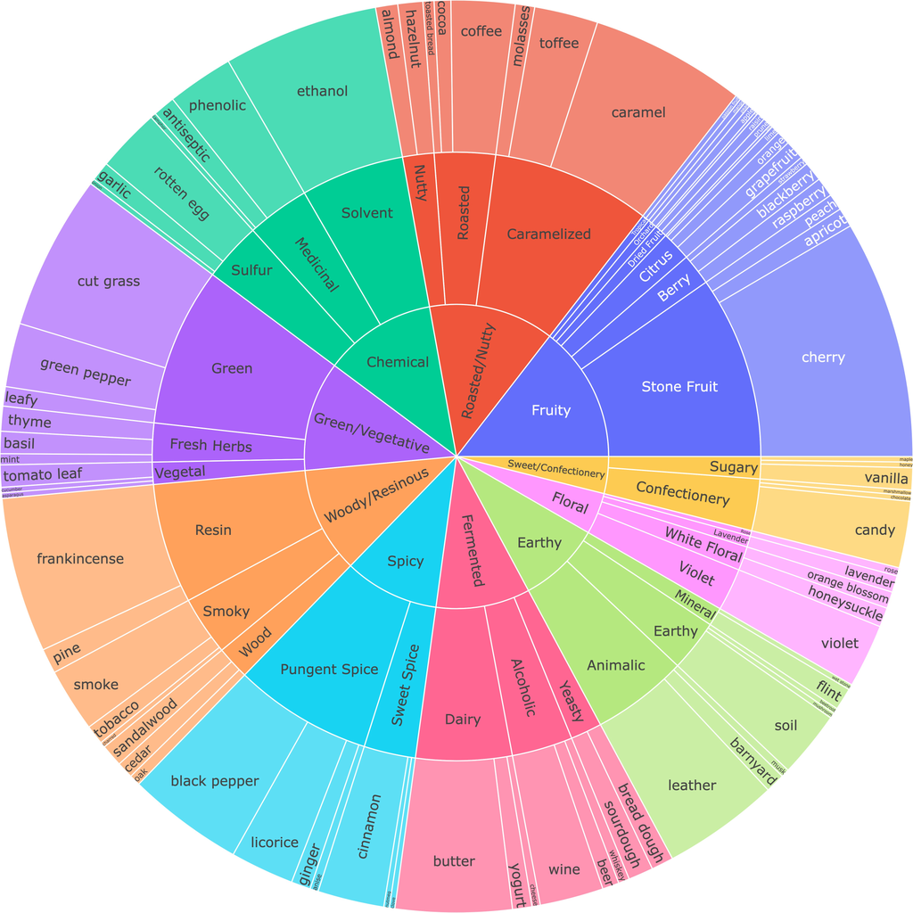

## Generating goodness-of-fit (GOF) index

If we consider the aroma components in a given wheel as a representation of the aroma composition and proportional representation of aroma classes, we can design a metric for GOF for a given product or group of products. The GOF index takes into account the proportional representation of each family/ major class. This concept comes from original consideration of aroma profile where the most abundant attributes are often and specifically elaborated. This means that attribute classes with more specific descriptors are more prevalent. Over-representation in this context is not calculated. This will be experimented with later.

|  | metric | value |
| --- | --- | --- |
| 0 | GOF index | 0.804516 |
| 1 | Number of unique attributes | 91.000000 |
| 2 | Fitted attributes | 83.000000 |
| 3 | Attributes not fitted | 8.000000 |

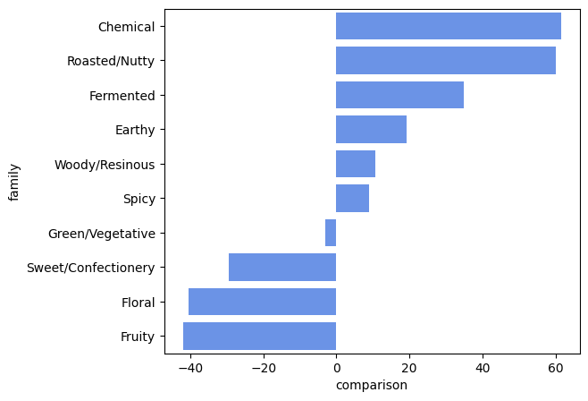

# Beer wheel generator: ASBC Beer Flavor Wheel, Second Edition

The terms were sourced from the American Society of Brewing Chemists (ASBC). The concept is the same as in the wine aroma construction. The template for the beer aroma wheel is as below.

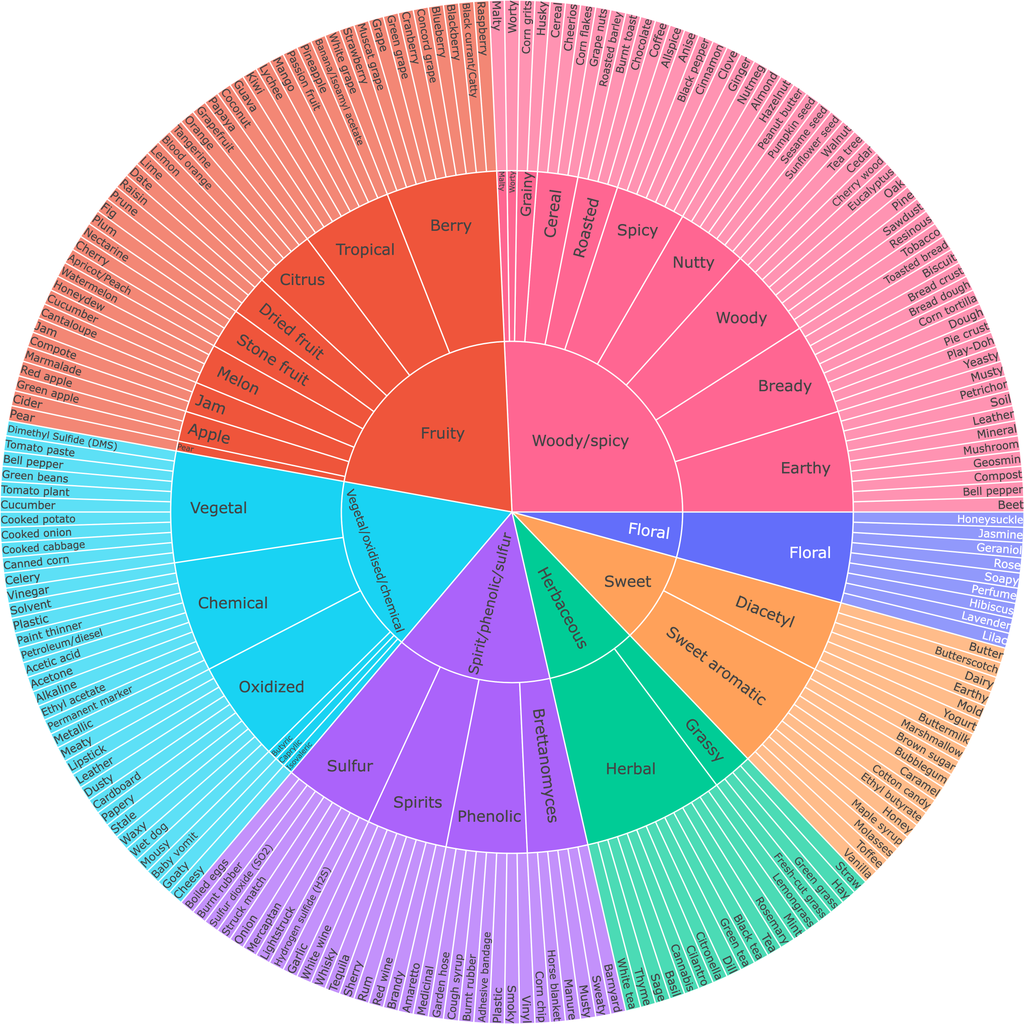

# Coffee wheel generator:

The concept is the same as in the wine and beer aroma construction. The example is from a published CATA coffee data. The data is processed as free-text first in order to execute the cleaning and wrangling procedure. This makes the CATA more compatible with this concept of sensory wheel construction.

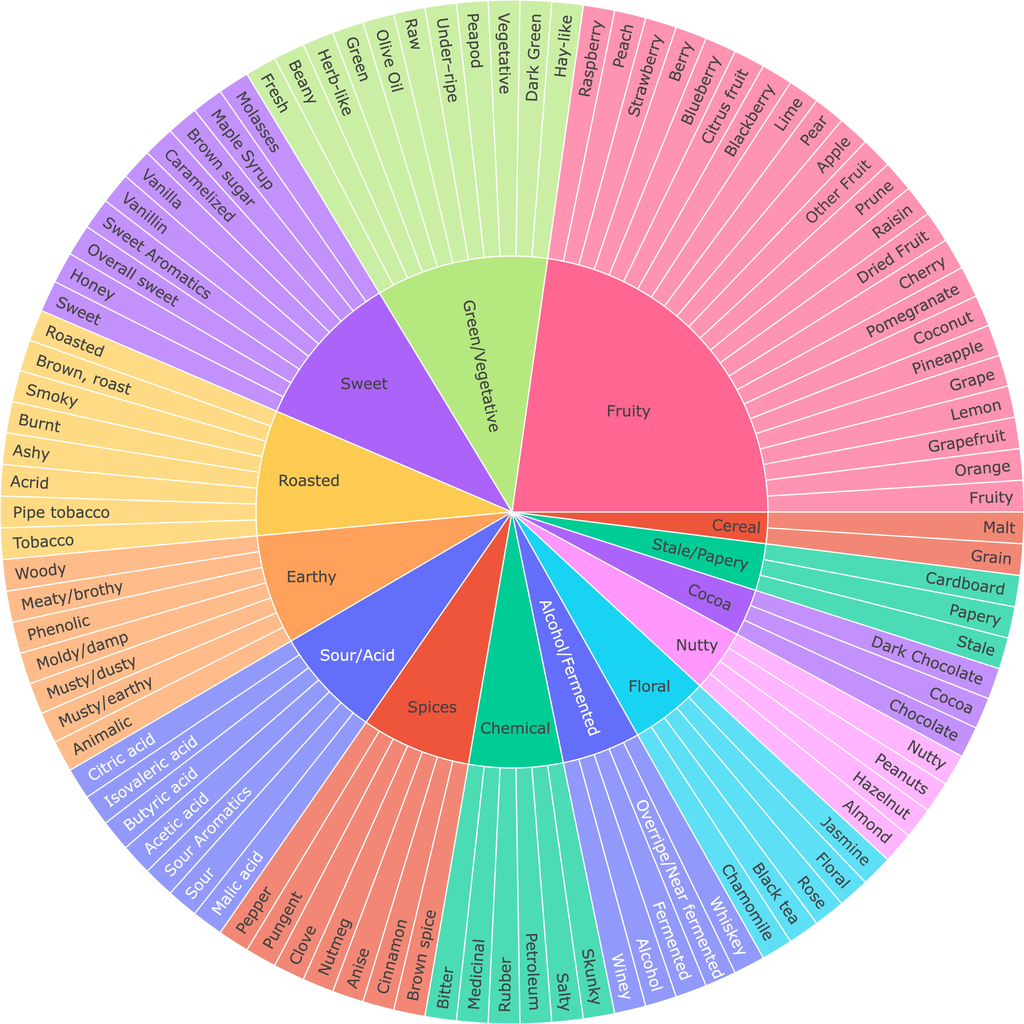